# Buzzard Survival

Meinolf Ottensmann

This document details all required steps to repeat analyses presented within our manuscript.

## Load required Packages

```r
rm(list = ls())
library(tidyverse)
library(magrittr)
library(patchwork)
library(RMark)
library(sjPlot)
library(sjlabelled)
library(sjmisc)
library(lme4)
library(forestmodel)
```

## Load raw data

### NAO indices

Here, we use NAO indices that are based on the principal component approach [^1] (Hurrel, 2003).

```r
nao <- read.table("data/nao.txt", header = T) %>%
  mutate(time = as.factor(year))
```

### buzzard data

This analysis is based on data from a longterm study on common buzzards *Buteo buteo* comprising 2499 individuals that were ringed as nestlings and individually marked with wingtags in the period 2007 to 2019. Note, due to logistic constraints there is no information on *Leucocytozoon* infections available for the cohort of 2008 and thus individuals from that cohort are omitted from analyses. There are two datasets, `ringing_data` containing morphometric measures of all individuals used for this analysis and `resighting_data` detailing resightings for these individuals.

```r
ringing_data <- as.data.frame(read_csv("data/ringing_data.csv"))
resighting_data <- as.data.frame(read_csv("data/resighting_data.csv"))
```

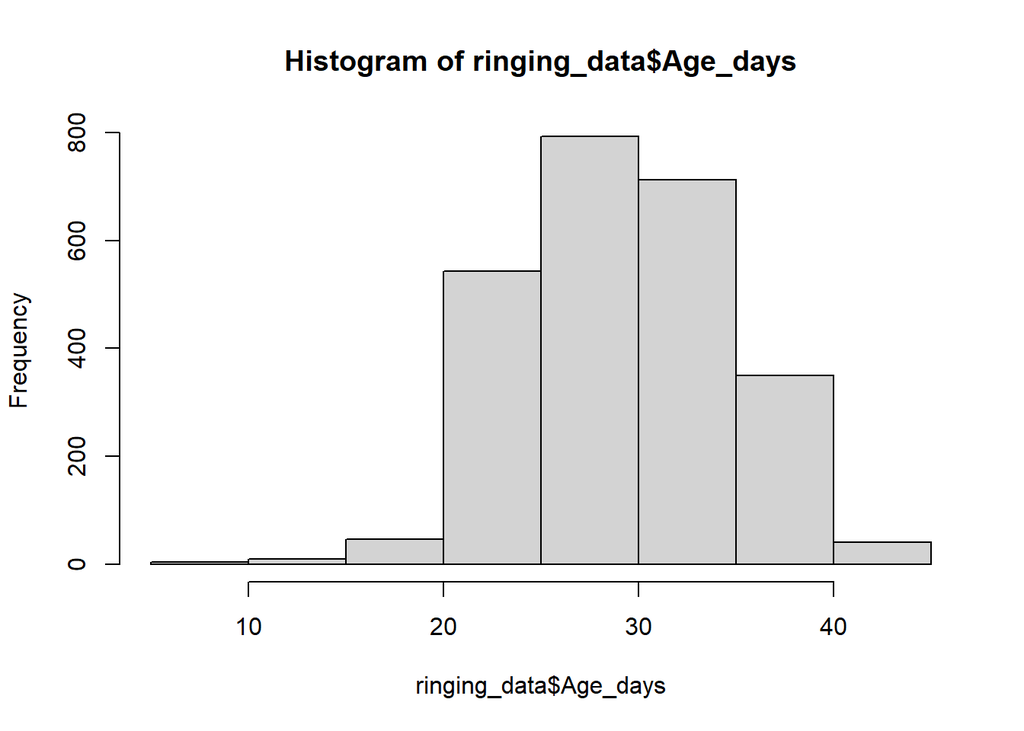

```r
## age distribution
hist(ringing_data$Age_days)
```

```r
quantile(ringing_data$Age_days, c(0.025, 0.975))
```

```
##     2.5%    97.5%
## 20.12795 39.29352
```

```r
mean(ringing_data$Age_days)
```

```
## [1] 29.15691
```

# Statistical Analysis

## Burnham model (Live & dead encounters)

We model survival probabilites using combined dead and live encounter events using the `Burnham` model in `MARK`.

Based on ringing data and resightings of individuals, we assemble combined live-dead encounter histories for all individuals using the function `create.ld`. This functions generates a vector of the form `LDLDLD`, where `L` codes live encounters and `D` dead recoveries respectively. Together, each `LD` pair codes for one interval of the study period.

```r
## function to derive encounter histories
create.ld <- function(start, end, ringing_data, resights) {
  ## Identify all individuals
  individuals <- ringing_data$Ring %>%
    unique()

  ## define Study periods based on start and end years
  years <- c(start, end)
  periods <- rep(seq(start, end), each = 1)

  ## create matrix
  ## rows: Individuals
  ## cols: 2 Periods per year with Live and Dead encounters respectively
  mat <- matrix(0, nrow = length(individuals), ncol = length(periods)*2) %>%
    set_colnames(paste0(rep(periods, each = 2), c("L", "D"))) %>%
    set_rownames(individuals)

  ## code year of capture as 1,
  ## Code sightings in subsequent intervals by 1 too
  for (x in individuals) {
    year.ringed <- filter(ringing_data, Ring == x)[["Year"]][1]
      ## code birth year in living encounters
      mat[rownames(mat) == x, colnames(mat) == paste0(year.ringed, "L")] <- 1

      ## get resights and assign to sampling instances. As years are defined
      ## by the period 01.04 to 31.03, the first three month of each year count
      ## for the preceding interval.
      year.resighted <-
        filter(resights, Ring == x)[,c("Year", "Month")] %>%
        mutate(period = case_when(
          Month == "01" ~ paste0(as.numeric(Year) - 1 , "L"),
          Month == "02" ~ paste0(as.numeric(Year) - 1 , "L"),
          Month == "03" ~ paste0(as.numeric(Year) - 1 , "L"),
          Month == "04" ~ paste0(Year, "L"),
          Month == "05" ~ paste0(Year, "L"),
          Month == "06" ~ paste0(Year, "L"),
          Month == "07" ~ paste0(Year, "L"),
          Month == "08" ~ paste0(Year, "L"),
          Month == "09" ~ paste0(Year, "L"),
          Month == "10" ~ paste0(Year, "L"),
          Month == "11" ~ paste0(Year, "L"),
          Month == "12" ~ paste0(Year, "L")
        ))

        ## write resights to matrix
  for (col in year.resighted$period) {
    mat[rownames(mat) == x, colnames(mat) == col] <- 1
  }

  ## check if reported as dead
  death <- filter(ringing_data, Ring == x)[,c("Dead", "DateDeath")][1,]
  if (!is.na(death$Dead)) {
    col <- paste0(substr(death$DateDeath, 1, 4),"D")
    mat[rownames(mat) == x, colnames(mat) == col] <- 1
  }

}

## coerce to character vector
return(apply(mat[,], 1, function(x) paste0(x, collapse = "")) %>%
         as.character())

}
```

Apply the function to the data:

```r
## add resighting histories to the ringing data
df <- data.frame(
  filter(ringing_data, !is.na(Lprev)),
  ch =  create.ld(start = 2007, # first year
                  end = 2020, # last year
                  ringing_data = ringing_data,
                  resights = resighting_data)) %>%
  mutate(ch = as.character(ch)) %>%
  mutate(Sex = as.factor(Sex)) %>%
  mutate(Hatch = scale(Hatch)) %>%
  mutate(Morh = case_when(
    Morph == "2" ~ "Dark",
    Morph == "3" ~ "Intermediate",
    Morph == "4" ~ "Light"
  )) %>%
  subset(.,
         select = -c(Ring, Rank, Hatch, Lbinom, Dead, DateDeath, CauseDeath))

## process the data for RMark
dp  <-  process.data(df, model = "Burnham",
                     begin.time = 2007, groups = "Sex")

## create design data
ddl <-  make.design.data(dp)

## Add design data for components
## Survival
ddl$S <- ddl$S %>%
  mutate(age = as.numeric(as.character(age))) %>%
  mutate(ageclass =
           case_when(
             age == 0 ~ "CY1",
             age == 1 ~ "CY2",
             age == 2 ~ "CY3",
             age >= 3 ~ "CY4plus"
           )) %>%
  mutate(ageclass2 = case_when(
             age == 0 ~ "CY1",
             age >= 1 ~ "CY2plus"
           ))

## collect variables which are year but not individual specific
covars <- left_join(data.frame(time = ddl$S$time), nao, "time")

## extend design data with covariates
ddl$S$djfm <- covars$djfm ## Winter NAO index

## Site-Fidelity
ddl$F <- ddl$F %>%
  mutate(age = as.numeric(as.character(age))) %>%
  mutate(ageclass =
           case_when(
             age == 0 ~ "CY1",
             age == 1 ~ "CY2",
             age == 2 ~ "CY3",
             age >= 3 ~ "CY4plus"
           )) %>%
  mutate(ageclass2 = case_when(
             age == 0 ~ "CY1",
             age >= 1 ~ "CY2plus"
           ))

## recovery chances
ddl$r <- ddl$r %>%
  mutate(age = as.numeric(as.character(age))) %>%
  mutate(ageclass =
           case_when(
             age == 0 ~ "CY1",
             age == 1 ~ "CY2",
             age == 2 ~ "CY3",
             age >= 3 ~ "CY4plus"
           )) %>%
  mutate(ageclass2 = case_when(
             age == 0 ~ "CY1",
             age >= 1 ~ "CY2plus"
           ))

## resight probability
ddl$p <- ddl$p %>%
  mutate(age = as.numeric(as.character(age))) %>%
  mutate(ageclass =
           case_when(
             age == 0 ~ "CY1",
             age == 1 ~ "CY2",
             age == 2 ~ "CY3",
             age >= 3 ~ "CY4plus"
           )) %>%
  mutate(ageclass2 = case_when(
             age == 0 ~ "CY1",
             age >= 1 ~ "CY2plus"
           ))
## Goodness of fit using RELEASE
release.gof(dp)
```

```
##       Chi.square df      P
## TEST2    22.2940 14 0.0728
## TEST3    13.0634 15 0.5974
## Total    35.3575 29 0.1930
```

```r
rm(covars); rm(nao);
```

### Bootstrapping Global model

```r
## not run, output is saved
source("R/bootstrapping.R")
## run global model to get parameter estimates
global.model <- mark(dp, ddl, silent = T, output = F,
                     model.parameters = list(
S = list(formula = ~ time*Sex),
p = list(formula = ~ time*Sex),
F = list(formula = ~ time*Sex),
r = list(formula = ~ time*Sex)),
model = 'Burnham')

## get model estimates/effects
params <- global.model$results$real

## get parameter names
components <- lapply(row.names(params), function(x) {
  stringr::str_split(x, pattern = " ")[[1]]
}) %>%
  do.call("rbind",.) %>%
  as.data.frame() %>%
  set_colnames(c("Estimate", "Group", "Cohort", "a", "t"))

## extract sex-specific components
S.female <-
  params$estimate[which(components$Estimate == "S" & components$Group == "gFemale")]
S.male <-
  params$estimate[which(components$Estimate == "S" & components$Group == "gMale")]
p.female <-
  params$estimate[which(components$Estimate == "p" & components$Group == "gFemale")]
p.male <-
  params$estimate[which(components$Estimate == "p" & components$Group == "gMale")]
F.female <-
  params$estimate[which(components$Estimate == "F" & components$Group == "gFemale")]
F.male <-
  params$estimate[which(components$Estimate == "F" & components$Group == "gMale")]
r.male <-
  params$estimate[which(components$Estimate == "r" & components$Group == "gMale")]
r.female <-
  params$estimate[which(components$Estimate == "r" & components$Group == "gFemale")]

## conduct simulations using parametric bs for both models
sim.out <- sims.burnham(
  S.fem = S.female,
  S.mal = S.male,
  p.fem = p.female,
  p.mal = p.male,
  F.fem = F.female,
  F.mal = F.male,
  r.fem = r.female,
  r.mal = r.male,
  marked =  Marked.burnham(data = df,
                   n.occasions = nchar(df$ch[1])/2,
                   groups = c("Female","Male"),
                   group.col = "Sex"),
  group.col = "Sex", reps = 9,
  model.parameters = list(
S = list(formula = ~ time*sex),
p = list(formula = ~ time*sex),
F = list(formula = ~ time*sex),
r = list(formula = ~ time*sex)))

save(sim.out, file = "data/sim.out.RData")
c.hat <- global.model$results$deviance/sim.out$deviance.mean
save(c.hat, file = "data/c.hat.RData")
cleanup(ask = F)
```

### Candidate models

The code below implements all candidate models. As the execution is computationally extensive the code is not executed by default but the output is provided within this repository.

```r
## not run, output is saved
## clear working space
#rm(list = c("ringing_data", "resighting_data", "df"))

do_analysis = function(dp, ddl, merge = F, suffix = NULL) {

  ## AGE4
  ## ###########################################################################
  S.2 = list(formula = ~ ageclass + Sex)
  S.2x = list(formula = ~ ageclass)

  S.3 = list(formula = ~ ageclass * cond + Sex)
  S.3x = list(formula = ~ ageclass * cond)

  S.4 = list(formula = ~ ageclass * cond + ageclass * djfm + Sex)
  S.4x = list(formula = ~ ageclass * cond + ageclass * djfm)

  # S.5 = list(formula = ~ ageclass * cond + ageclass * djfm + ageclass * Hatch + Sex)
  # S.5x = list(formula = ~ ageclass * cond + ageclass * djfm + ageclass * Hatch)

  S.9 = list(formula = ~ ageclass * cond + ageclass * Ekto + ageclass * Lprev + Sex + Morph)
  S.9x = list(formula = ~ ageclass * cond + ageclass * Ekto + ageclass * Lprev + Morph)

  S.5 = list(formula = ~ ageclass * cond + ageclass * Ekto + ageclass * Lprev + Sex )
  S.5x = list(formula = ~ ageclass * cond + ageclass * Ekto + ageclass * Lprev)

  S.11 = list(formula = ~ageclass * cond + ageclass * djfm + ageclass * Ekto + Morph + Sex)
  S.11x = list(formula = ~ageclass * cond + ageclass * djfm + ageclass * Ekto + Morph)

  S.8 = list(formula = ~ ageclass * cond + ageclass * djfm + ageclass * Ekto + ageclass * Lprev + Morph + Sex)
  S.8x = list(formula = ~ ageclass * cond + ageclass * djfm + ageclass * Ekto + ageclass * Lprev + Morph)

  S.13 = list(formula = ~ ageclass * cond + ageclass * djfm + ageclass * Ekto + ageclass * Lprev + Sex)
  S.13x = list(formula = ~ ageclass * cond + ageclass * djfm + ageclass * Ekto + ageclass * Lprev)

  S.12 = list(formula = ~ ageclass * cond + ageclass * djfm + ageclass * Ekto + Sex)
  S.12x = list(formula = ~ ageclass * cond + ageclass * djfm + ageclass * Ekto)

  S.15 = list(formula = ~ ageclass * cond + ageclass * djfm + ageclass * Lprev + Sex)
  S.15x = list(formula = ~ ageclass * cond + ageclass * djfm + ageclass * Lprev)

  # S.13 = list(formula = ~ageclass * cond + ageclass * Ekto + ageclass * Hatch + ageclass * Lprev + Morph + Sex)
  # S.13x = list(formula = ~ageclass * cond + ageclass * Ekto + ageclass * Hatch + ageclass * Lprev + Morph)

  # S.15 = list(formula = ~ageclass * cond + ageclass * djfm + ageclass * Ekto + ageclass * Hatch + Morph + Sex)
  # S.15x = list(formula = ~ageclass * cond + ageclass * djfm + ageclass * Ekto + ageclass * Hatch + Morph)
  #
  # S.12 = list(formula = ~ageclass * cond + ageclass * djfm + ageclass * Ekto + ageclass * Hatch + ageclass * Lprev + Morph + Sex)
  # S.12x = list(formula = ~ageclass * cond + ageclass * djfm + ageclass * Ekto + ageclass * Hatch + ageclass * Lprev + Morph)

  S.3b = list(formula = ~ ageclass + cond + Sex)
  S.3bz = list(formula = ~ ageclass + cond)

  S.4b = list(formula = ~ ageclass + cond + djfm + Sex)
  S.4bz = list(formula = ~ ageclass + cond + djfm)

  # S.5b = list(formula = ~ ageclass + cond + djfm + Hatch + Sex)
  # S.5bz = list(formula = ~ ageclass + cond + djfm + Hatch)

  S.9b = list(formula = ~ ageclass + cond + Ekto + Lprev + Morph + Sex)
  S.9bz = list(formula = ~ ageclass + cond + Ekto + Lprev + Morph)

  S.5b = list(formula = ~ ageclass + cond + Ekto + Lprev + Sex)
  S.5bz = list(formula = ~ ageclass + cond + Ekto + Lprev)

  S.11b = list(formula = ~ageclass + cond + djfm  + Ekto  + Morph + Sex)
  S.11bz = list(formula = ~ageclass + cond + djfm  + Ekto  + Morph)

  S.13b = list(formula = ~ageclass + cond + djfm  + Ekto + Sex)
  S.13bz = list(formula = ~ageclass + cond + djfm  + Ekto)

  S.8b = list(formula = ~ ageclass + cond + djfm + Ekto + Lprev + Morph + Sex)
  S.8bz = list(formula = ~ ageclass + cond + djfm + Ekto + Lprev + Morph)

  # S.13b = list(formula = ~ageclass + cond + Ekto + Hatch + Lprev + Morph + Sex)
  # S.13bz = list(formula = ~ageclass + cond + Ekto + Hatch + Lprev + Morph)

  # S.15b = list(formula = ~ageclass + cond + djfm + Ekto + Hatch + Morph + Sex)
  # S.15bz = list(formula = ~ageclass + cond + djfm + Ekto + Hatch + Morph)

  S.6 = list(formula = ~ ageclass * djfm + Sex)
  S.6x = list(formula = ~ ageclass * djfm)

  # S.7 = list(formula = ~ ageclass * djfm + ageclass * Hatch + Sex)
  # S.7x = list(formula = ~ ageclass * djfm + ageclass * Hatch)

  S.10 = list(formula = ~ageclass * djfm + ageclass * Ekto + ageclass * Lprev +  Morph + Sex)
  S.10x = list(formula = ~ageclass * djfm + ageclass * Ekto + ageclass * Lprev +  Morph)

  # S.14 = list(formula = ~ageclass * djfm + ageclass * Ekto + ageclass * Hatch + ageclass * Lprev + Morph + Sex)
  # S.14x = list(formula = ~ageclass * djfm + ageclass * Ekto + ageclass * Hatch + ageclass * Lprev + Morph)

  S.6b = list(formula = ~ ageclass + djfm + Sex)
  S.6bz = list(formula = ~ ageclass + djfm)

  # S.7b = list(formula = ~ ageclass + djfm + Hatch + Sex)
  # S.7bz = list(formula = ~ ageclass + djfm + Hatch)

  S.10b = list(formula = ~ageclass + djfm + Ekto + Lprev + Morph + Sex)
  S.10bz = list(formula = ~ageclass + djfm + Ekto + Lprev + Morph)

  S.14b = list(formula = ~ageclass + djfm + Ekto + Lprev + Sex)
  S.14bz = list(formula = ~ageclass + djfm + Ekto + Lprev)

  # S.14b = list(formula = ~ageclass + djfm + Ekto + Hatch + Lprev + Morph + Sex)
  # S.14bz = list(formula = ~ageclass + djfm + Ekto + Hatch + Lprev + Morph)

  #p.dot = list(formula = ~ 1)
  p.age = list(formula = ~ ageclass)
  #p.age2 = list(formula = ~ ageclass2)
  p.time = list(formula = ~ time)
  p.time.age = list(formula = ~ time + ageclass)
  #p.time.age2 = list(formula = ~ time + ageclass2)

  F.dot = list(formula = ~ 1)
  F.age = list(formula = ~ ageclass)
  F.age.sex = list(formula = ~ ageclass + Sex)
  #F.age2 = list(formula = ~ ageclass2)
  #F.age2.sex = list(formula = ~ ageclass2 + Sex)
  F.Sex = list(formula = ~ Sex)

  #r.dot = list(formula = ~ 1)
  #r.age = list(formula = ~ ageclass)
  r.age2 = list(formula = ~ ageclass2)

  cml = create.model.list(model = "Burnham")
  save(cml, file = "data/cml.temp.RData")

  # only run new models
  if (isTRUE(merge) & !is.null(suffix)) {
  load(paste0("cml.", suffix, ".RData"))
    cml <- anti_join(cml, cml.old)
  }

  ## split task
  split <- c(round(seq(0, nrow(cml), length.out = 10)))

  for (i in 1:(length(split)-1)) {
  # run all models and return as a list with class 'marklist'
   pb <- utils::txtProgressBar(min = 1, max = length(split) -1,
                               style = 3, char = "+", width = 80)
   utils::setTxtProgressBar(pb, i)

   results = mark.wrapper.parallel(cml[(split[i] + 1):split[i + 1],],
                                   data = dp,
                                   ddl = ddl,
                                   output = F,
                                   silent = T,
                                   cpus = 4)
   save(results, file = paste0("data/results", i, ".RData"))
   rm(results)
  }

  ## merge results
  indices <- data.frame(first = split[1:9] + 1,
            last = split[2:10],
            n = diff(split)
  )

  cat("Merge results ... \n")
  cat("1 out of 10 \n")
  load("data/results1.RData"); results1 <- results; rm(results)

  cat("2 out of 10 \n")
  load("data/results2.RData"); results2 <- results; rm(results)
  names(results2)[1:indices$n[2]] <-  paste0("model", indices$first[2]:indices$last[2])
  results.comb <- merge.mark(results1, results2); rm(results1); rm(results2)

  cat("3 out of 10\n")
  load("data/results3.RData")
  names(results)[1:indices$n[3]] <-  paste0("model", indices$first[3]:indices$last[3])
  results.comb <- merge.mark(results.comb, results); rm(results)

  cat("4 out of 10\n")
  load("data/results4.RData")
  names(results)[1:indices$n[4]] <-  paste0("model", indices$first[4]:indices$last[4])
  results.comb <- merge.mark(results.comb, results); rm(results)

  cat("5 out of 10\n")
  load("data/results5.RData")
  names(results)[1:indices$n[5]] <-  paste0("model", indices$first[5]:indices$last[5])
  results.comb <- merge.mark(results.comb, results); rm(results)

  cat("6 out of 10\n")
  load("data/results6.RData")
  names(results)[1:indices$n[6]] <-  paste0("model", indices$first[6]:indices$last[6])
  results.comb <- merge.mark(results.comb, results); rm(results)

  cat("7 out of 10\n")
  load("data/results7.RData")
  names(results)[1:indices$n[7]] <-  paste0("model", indices$first[7]:indices$last[7])
  results.comb <- merge.mark(results.comb, results); rm(results)

  cat("8 out of 10\n")
  load("data/results8.RData")
  names(results)[1:indices$n[8]] <-  paste0("model", indices$first[8]:indices$last[8])
  results.comb <- merge.mark(results.comb, results); rm(results)

  cat("9 out of 10\n")
  load("data/results9.RData")
  names(results)[1:indices$n[9]] <-  paste0("model", indices$first[9]:indices$last[9])
  results.comb <- merge.mark(results.comb, results); rm(results)

  return(results.comb)
}

# if (!is.null(suffix)) {
# load(paste0("data/models.", suffix, ".RData"))
# assign(paste0("models.old"), models)
# }
models <- do_analysis(dp = dp, ddl = ddl, merge = F, suffix = NULL)

## only temp
#rm(ddl); rm(dp)

# if (!is.null(suffix)) {
# models <- merge.mark(models, models.old)
# }

## find duplicated models
# mt <- model.table(models, sort = F)
# to.remove <- which(duplicated(mt$model))
# ## remove
# models <- remove.mark(
#   marklist = models,
#   model.numbers = to.remove)

## adjust for overdispersion using c-hat
load("data/c.hat.RData")
models.adj <-  adjust.chat(model.list = models, chat = c.hat)

## Select supported models
supported.models <- remove.mark(
  marklist = models.adj,
  model.numbers = which(model.table(models.adj, sort = F)[["DeltaQAICc"]] > 10))

suffix <- Sys.time() %>%
  as.character() %>%
  stringr::str_remove(., " ") %>%
  gsub(pattern = ":", replacement = "-", x = .)

## save cml object
load("data/cml.temp.RData")
assign(paste0("cml.old"), cml)
save(cml.old, file = paste0("cml.", suffix, ".RData"))

save(suffix, file = paste0("data/",suffix,".RData"))
save(models, file = paste0("data/models.", suffix, ".RData"))
save(models.adj, file = paste0("data/models.adj.", suffix, ".RData"))
save(supported.models, file = paste0("data/supported.models.", suffix, ".RData"))
cleanup(ask = F)
```

### Results

As the execution of the models is time consuming, we provide the captured output as part of the repository

```r
## load previously saved results
suffix <- "2020-10-1901-29-29"
## all models
#load(paste0("data/models.", suffix, ".RData"))
## models with adjusted deviance
load(paste0("data/models.adj.", suffix, ".RData"))
## models within DeltaQAICc <= 10 of the top ranking
load(paste0("data/supported.models.", suffix, ".RData"))
```

In total we evaluated 528models, of which 84 where supported to a variable extend by the data (i.e. within $\Delta QAIC_c <= 10$ of the top model)

```r
model.table <-supported.models$model.table[,c("model", "DeltaQAICc", "weight", "npar", "QDeviance")]
readr::write_csv(model.table, "data/supported.models.csv")

model.table <-models.adj$model.table[,c("model", "DeltaQAICc", "weight", "npar", "QDeviance")]
readr::write_csv(model.table, "data/adjusted.models.csv")
```

#### Model averaging

```r
## Model average Survival estimates (S)
S.mod.avg <- model.average(
  remove.mark(
    marklist = supported.models,
    model.numbers = which(model.table(supported.models, sort = F)[["DeltaQAICc"]] > 7)),
  parameter = "S", drop = T, vcv = T)[["estimates"]] %>%
  subset(., select = c(estimate, se, lcl, ucl, age, Sex))

## Model average Fidelity estimates (F)
F.mod.avg <- model.average(supported.models, parameter = "F", vcv = T, drop = T)$estimates %>%
  subset(., select = (c(estimate, se, lcl, ucl, time, age, Sex))) %>%
  unique.data.frame()

## Model average recovery estimates (r)
r.mod.avg <- model.average(supported.models, parameter = "r", vcv = T, drop = T)$estimates %>%
  subset(., select = (c(estimate, se, lcl, ucl, time, age, Sex))) %>%
  unique.data.frame()

## Model average resighting estimates (p)
p.mod.avg <- model.average(supported.models, parameter = "p", vcv = T, drop = T)$estimates %>%
  subset(., select = (c(estimate, se, lcl, ucl, time, age))) %>%
  unique.data.frame()
```

#### Survival probabilites

Mean estimates for age and sex combinations over time

```r
estimates <- S.mod.avg %>%
  mutate(AgeGroup = case_when(
    age == 0 ~ "CY1",
    age == 1 ~ "CY2",
    age == 2 ~ "CY3",
    age %in% 3:13 ~ "CY4+"
  ))

(DBChecks::summary_stats(estimates,
                        measurevar = "estimate",
                        groupvars = c("Sex", "AgeGroup")))
```

```
##      Sex AgeGroup  N  estimate         sd        q1        q3       lci
## 1 Female      CY1 14 0.4806288 0.04881275 0.4598833 0.5074017 0.3804669
## 2 Female      CY2 13 0.5776091 0.12278364 0.5297282 0.6426662 0.3329832
## 3 Female      CY3 12 0.7432106 0.09985097 0.7103014 0.8040899 0.5416718
## 4 Female     CY4+ 66 0.8838237 0.07880066 0.8990569 0.9393861 0.6734455
## 5   Male      CY1 14 0.4208724 0.04706769 0.4001735 0.4466288 0.3251022
## 6   Male      CY2 13 0.5207625 0.12240708 0.4688473 0.5849760 0.2816397
## 7   Male      CY3 12 0.6965328 0.10822210 0.6578343 0.7627914 0.4812215
## 8   Male     CY4+ 66 0.8578063 0.08969585 0.8740758 0.9233145 0.6187391
##         uci         se
## 1 0.5338012 0.01304576
## 2 0.7078213 0.03405406
## 3 0.8402500 0.02882449
## 4 0.9427201 0.00969969
## 5 0.4729550 0.01257937
## 6 0.6550719 0.03394962
## 7 0.8045883 0.03124103
## 8 0.9274362 0.01104080
```

##### Age

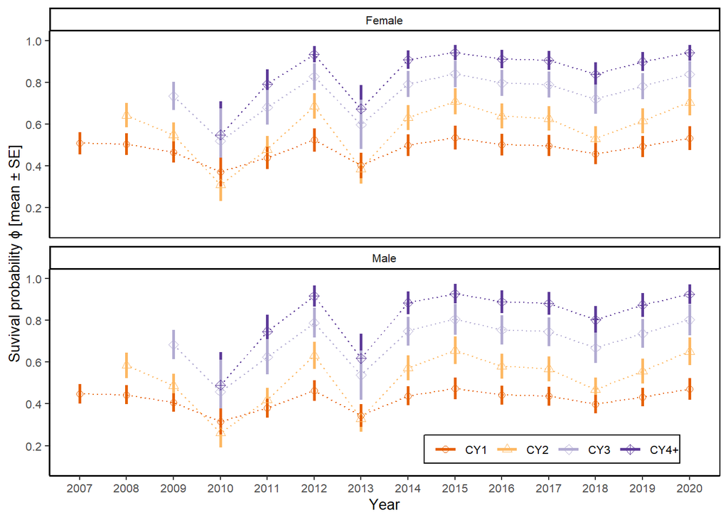

```r
## derive ageclass-specfic annual survival estimates
df.S.age <- lapply(rownames(S.mod.avg), function(row) {
  x <- stringr::str_split(row, " ")[[1]]
  data.frame(parameter = x[1],
             cohort = substr(x[3], 2, nchar(x[3])),
             year = as.numeric(substr(x[5], 2, nchar(x[5]))))
}) %>%
  do.call("rbind",.) %>%
  cbind(S.mod.avg) %>%
  mutate(ageclass = case_when(
    age == 0 ~ 'CY1',
    age == 1 ~ 'CY2',
    age == 2 ~ 'CY3',
    age %in% 3:13 ~ 'CY4plus' ## 3:13 are identical
  ))

p.age <-
  ggplot(filter(df.S.age, age %in% 0:3), aes(x = year, y = estimate, group = age)) +
  geom_line(lty = "dotted", aes(col = age)) +
  geom_errorbar(aes(ymin = estimate - se, ymax = estimate +se,  color = age), width = 0, size = 1) +
  geom_point(aes(col = age, shape = age), size = 2) +
  theme_classic() +
  theme(
    axis.line = element_line(size = .7, color = "black"),
    # axis.text.x = element_blank(),
    # axis.title.x = element_blank(),
    # axis.ticks.x = element_blank(),
    legend.background = element_rect(fill = NA, colour = "Black"),
    legend.margin = margin(c(1,1,1,1)),
    legend.direction = "horizontal",
    legend.position = c(0.75, 0.06),
    panel.background = element_rect(fill = NA),
    panel.border = element_rect(fill = NA),
    text = element_text(size = 10)) +
  scale_color_brewer(palette = "PuOr",
                     labels = c("CY1", "CY2", "CY3", "CY4+"),
                     name = "") +
  scale_shape_manual(values = c(1, 2, 5, 9),
                     labels = c("CY1", "CY2", "CY3", "CY4+"),
                     name = "") +
  scale_y_continuous(limits = c(0.1, 1),
                     breaks = seq(0, 1, .2)) +
  scale_x_continuous(breaks = seq(2007, 2020, 1),
                     limits = c(2007, 2020)) +
  xlab("Year") +
  ylab("Suvival probability \U03D5 [mean \U00B1 SE]") +
  facet_wrap(~Sex, ncol = 1, strip.position = "top")
p.age
```

```r
ggsave("plots/Fig_1_AgeEffect.tiff", device = "tiff", dpi = 300, width = 6, height = 4, units = "in")
```

##### NAO

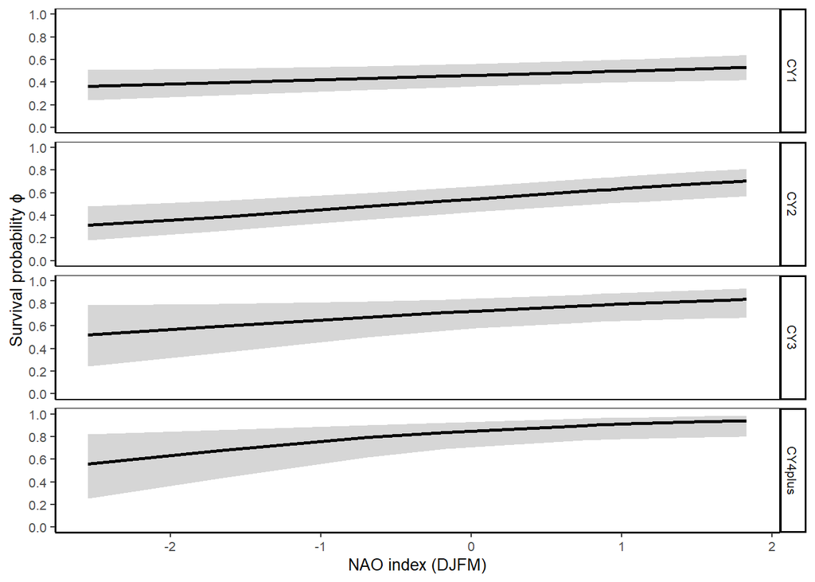

```r
djfm.values = ddl$S$djfm %>% unique()

## Extract get par.index of interest
index.meta <- data.frame(
  ageclass = rep(c("CY1", "CY2", "CY3", "CY4plus"), 1)) %>%
  ## add par.index
  left_join(., ddl$S[,c("par.index", "ageclass", "djfm")]) %>%
  ## code additional vars
  mutate(dummy = paste0(djfm, ageclass))

## simplify, one par.index for each dummy var.
model.indices <- sapply(unique(index.meta$dummy), function(x) {
  ## return first row matching the query
  index.meta[index.meta$dummy == x,"par.index"][1]
}) %>%
  unlist()

index.meta <- index.meta[index.meta$par.index %in% model.indices,]

pred.djfm <- covariate.predictions(
  model = supported.models,
  data = data.frame(
    djfm = djfm.values),
  indices = index.meta$par.index)[["estimates"]]

## extend df with grouping variables
pred.model <- left_join(
  pred.djfm,
  index.meta[,c("par.index", "ageclass")],
  by = "par.index") %>%
  mutate(Group = ageclass)

pred.model <- left_join(
  index.meta,
  pred.model[,c("par.index", "estimate", "lcl", "ucl", "se", "ageclass", "Group")]) %>%
  unique.data.frame()


p.djfm <-
  ggplot(pred.model, aes(x = djfm, y = estimate, group = Group)) +
  geom_line(size = 1) +
  geom_ribbon(aes(ymin = lcl,
                  ymax = ucl),
              alpha = 0.2) +

  theme_classic() +
  theme(
    axis.line = element_line(size = .7, color = "black"),
    panel.background = element_rect(fill = NA),
    panel.border = element_rect(fill = NA),
    text = element_text(size = 10)) +
  scale_y_continuous(limits = c(0,1),
                     breaks = seq(0, 1, 0.2)) +
  xlab("NAO index (DJFM)") +
  ylab("Survival probability \U03D5") +
  facet_wrap(~ageclass, ncol = 1,
             strip.position = "right")
p.djfm
```

```r
ggsave("plots/Fig_2_NAOEffect.tiff", device = "tiff", dpi = 300, width = 4, height = 6, units = "in")
```

##### Condition

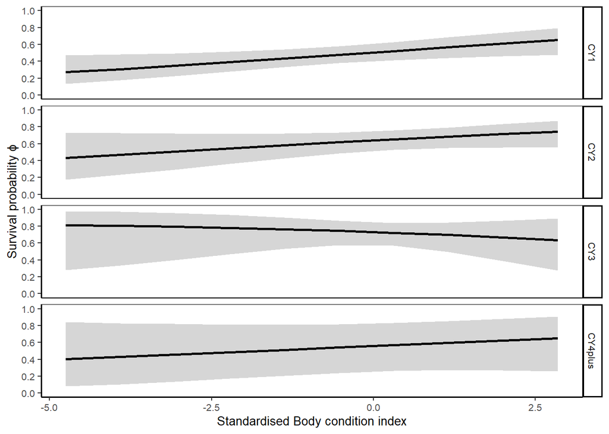

```r
# create values of cond.index to use for predictions
cond.index.values = seq(from = min(df$cond), to = max(df$cond), length.out = 10)

## Extract get 'par.index' of interest
index.meta <- data.frame(
  Sex = rep(c("Female", "Male"), each = 4),
  ageclass = rep(c("CY1", "CY2", "CY3", "CY4plus"), 2)) %>%
  ## add par.index
  left_join(., ddl$S[,c("par.index", "Sex", "ageclass")],
            by = c("Sex", "ageclass")) %>%
  ## code additional vars
  mutate(dummy = paste0(Sex, ageclass))

## simplify, one par.index for each dummy var
model.indices <- sapply(unique(index.meta$dummy), function(x) {
  ## return first row matching the query
  index.meta[index.meta$dummy == x,"par.index"][1]
}) %>%
  unlist()

## subset index.meta
index.meta <- index.meta[index.meta$par.index %in% model.indices,]

## get estimates from the model
pred.model <- covariate.predictions(
  supported.models,
  data = data.frame(
    cond = cond.index.values),
  indices = model.indices %>% as.numeric(),
  drop = T)[["estimates"]]

## extend df with grouping variables
pred.model <- left_join(pred.model,
                        index.meta[,c("par.index", "ageclass", "Sex")],
                        by = "par.index") %>%
  mutate(Group = paste0(Sex, ageclass))

## only showing estimates for females,  as sex-difference is small and additive,
## whereby only the intercept but not the response varies
p.cond <-
  ggplot(filter(pred.model, Sex ==  "Female"), aes(x = covdata, y = estimate, group = Group)) +
  geom_line(size = 1) +
  geom_ribbon(aes(ymin = lcl,
                  ymax = ucl),
              alpha = 0.2) +

  theme_classic() +
  theme(
    axis.line = element_line(size = .7, color = "black"),
    panel.background = element_rect(fill = NA),
    panel.border = element_rect(fill = NA),
    text = element_text(size = 10)) +
  xlab("Standardised Body condition index") +
  ylab("Survival probability \U03D5") +
  facet_wrap(~ageclass, ncol = 1,
             strip.position = "right") +
  scale_y_continuous(limits = c(0,1),
                     breaks = seq(0, 1, 0.2))
p.cond
```

```r
ggsave("plots/Fig_3_BCI_Effect.tiff", device = "tiff", dpi = 300, width = 4, height = 6, units = "in")
```

##### Leucocytozoon

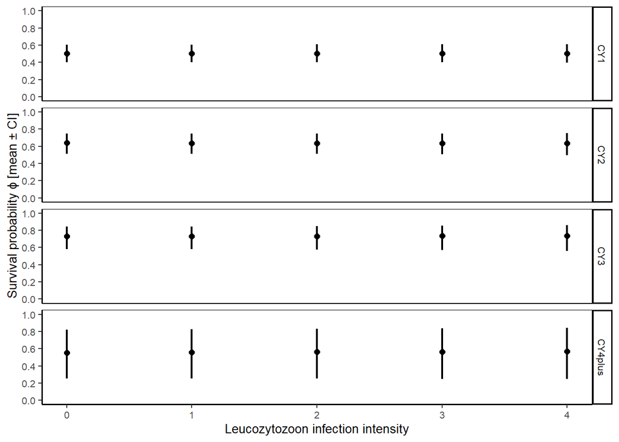

```r
leuco = 0:4

## Extract get par.index of interest
index.meta <- data.frame(
  ageclass = rep(c("CY1", "CY2", "CY3", "CY4plus"), 1)) %>%
  ## add par.index
  left_join(., ddl$S[,c("par.index", "ageclass")]) %>%
  ## code additional vars
  mutate(dummy = paste0(ageclass))

## simplify, one par.index for each dummy var
model.indices <- sapply(unique(index.meta$dummy), function(x) {
  ## return first row matching the query
  index.meta[index.meta$dummy == x,"par.index"][1]
}) %>%
  unlist()

index.meta <- index.meta[index.meta$par.index %in% model.indices,]

pred.leuco <- covariate.predictions(
  supported.models,
  data = data.frame(
    Lprev = leuco),
  indices = index.meta$par.index)[["estimates"]]

## extend df with grouping variables
pred.model <- left_join(pred.leuco, index.meta[,c("par.index", "ageclass")], by = "par.index") %>%
  mutate(Group = ageclass)

pred.model <- left_join(index.meta, pred.model[,c("par.index", "covdata", "estimate", "lcl", "ucl", "se", "ageclass", "Group")]) %>%
  unique.data.frame()

p.leuco <-
  ggplot(pred.model, aes(x = covdata, y = estimate, group = ageclass)) +
  geom_errorbar(aes(ymin = lcl, ymax = ucl), width = 0, size = 0.75) +
  geom_point(size = 3, colour = "Black", shape = 20) +
  theme_classic() +
  theme(
    axis.line = element_line(size = .7, color = "black"),
    panel.background = element_rect(fill = NA),
    panel.border = element_rect(fill = NA),
    text = element_text(size = 10)) +
  scale_y_continuous(limits = c(0,1),
                     breaks = seq(0, 1, 0.2)) +
  xlab("Leucozytozoon infection intensity") +
  ylab("Survival probability \U03D5 [mean \U00B1 CI]") +
  facet_wrap(~ageclass, ncol = 1,
             strip.position = "right")
p.leuco
```

```r
ggsave("plots/Fig_4_Leucocytozoon_Effect.tiff", device = "tiff", dpi = 300, width = 4, height = 6, units = "in")
```

##### Carnus

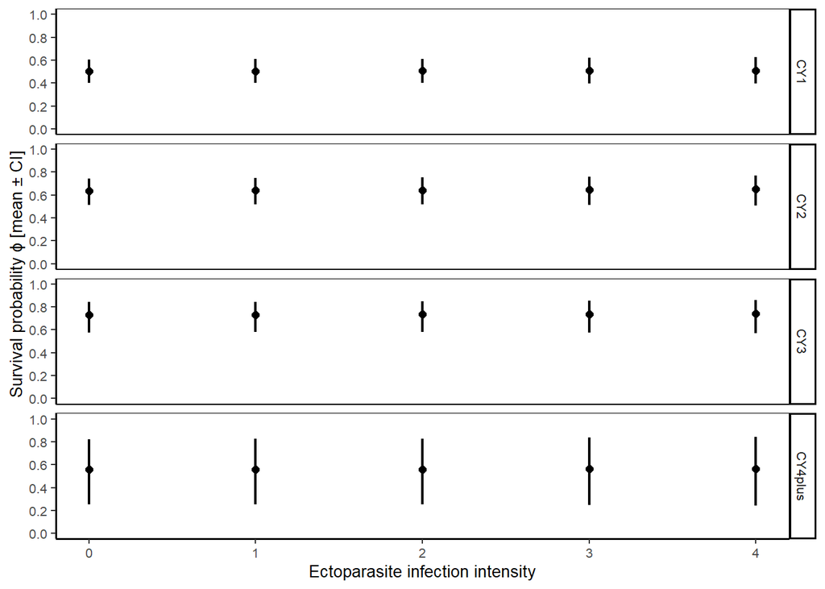

```r
ekto = 0:4

## Extract get par.index of interest
index.meta <- data.frame(
  ageclass = rep(c("CY1", "CY2", "CY3", "CY4plus"), 1)) %>%
  ## add par.index
  left_join(., ddl$S[,c("par.index", "ageclass")]) %>%
  ## code additional vars
  mutate(dummy = paste0(ageclass))

## simplify, one par.index for each dummy var
model.indices <- sapply(unique(index.meta$dummy), function(x) {
  ## return first row matching the query
  index.meta[index.meta$dummy == x,"par.index"][1]
}) %>%
  unlist()

index.meta <- index.meta[index.meta$par.index %in% model.indices,]

pred.ekto <- covariate.predictions(
  supported.models,
  data = data.frame(
    Ekto = ekto),
  indices = index.meta$par.index)[["estimates"]]

## extend df with grouping variables
pred.model <- left_join(pred.ekto, index.meta[,c("par.index", "ageclass")], by = "par.index") %>%
  mutate(Group = ageclass)

pred.model <- left_join(index.meta, pred.model[,c("par.index", "covdata", "estimate", "lcl", "ucl", "ageclass", "Group")]) %>%
  unique.data.frame()

p.ekto <-
  ggplot(pred.model, aes(x = covdata, y = estimate, group = ageclass)) +
  geom_errorbar(aes(ymin = lcl, ymax = ucl), width = 0, size = 0.75) +
  geom_point(size = 3, colour = "Black", shape = 20) +
  theme_classic() +
  theme(
    axis.line = element_line(size = .7, color = "black"),
    panel.background = element_rect(fill = NA),
    panel.border = element_rect(fill = NA),
    text = element_text(size = 10)) +
  scale_y_continuous(limits = c(0,1),
                     breaks = seq(0, 1, 0.2)) +
  xlab("Ectoparasite infection intensity") +
  ylab("Survival probability \U03D5 [mean \U00B1 CI]") +
  facet_wrap(~ageclass, ncol = 1,
             strip.position = "right")

p.ekto
```

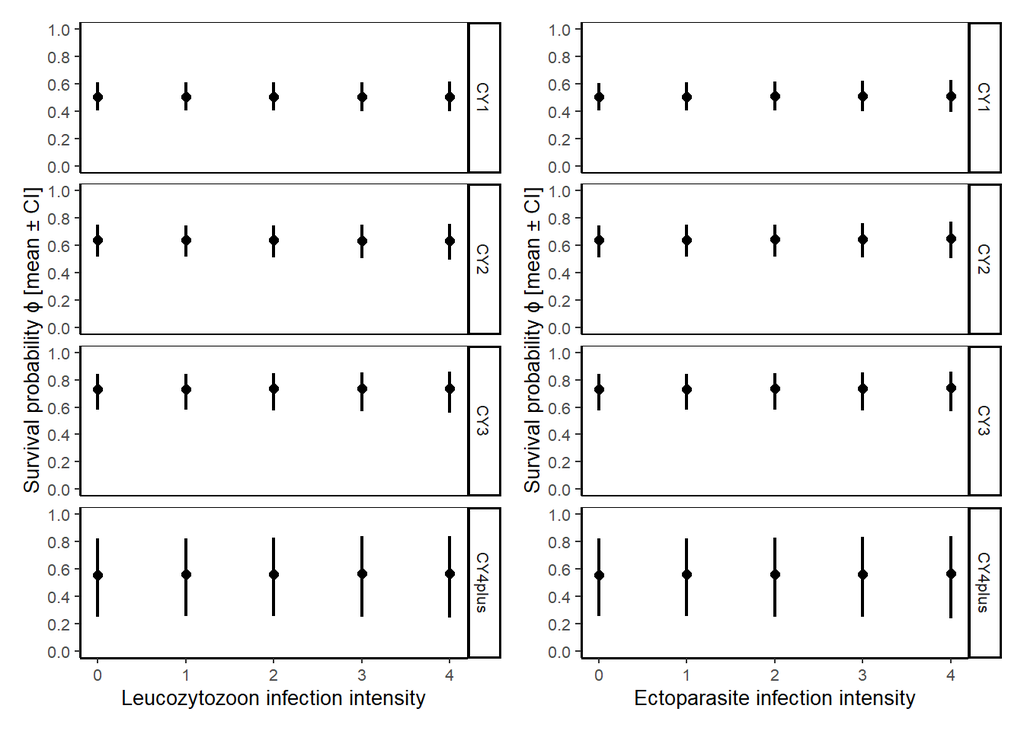

```r
ggsave("plots/Fig_5_Carnus_Effect.tiff", device = "tiff", dpi = 300, width = 4, height = 6, units = "in")

## multiplot
p.ekto2 <- p.ekto +
  theme(axis.text.y = element_blank(),
        axis.title.y = element_blank(),
        axis.ticks.y = element_blank())
p.leuco + p.ekto
```

```r
ggsave("plots/Fig_6_Leuco-Carnus_Effect.tiff", device = "tiff", dpi = 300, width = 6, height = 4, units = "in")
```

#### Resighting probabilies

All supported models (i.e. within $\Delta QAIC_C <=10$) contained a time-dependent component of the resighting probability, while a subset included an additive effect of Age (four classes).

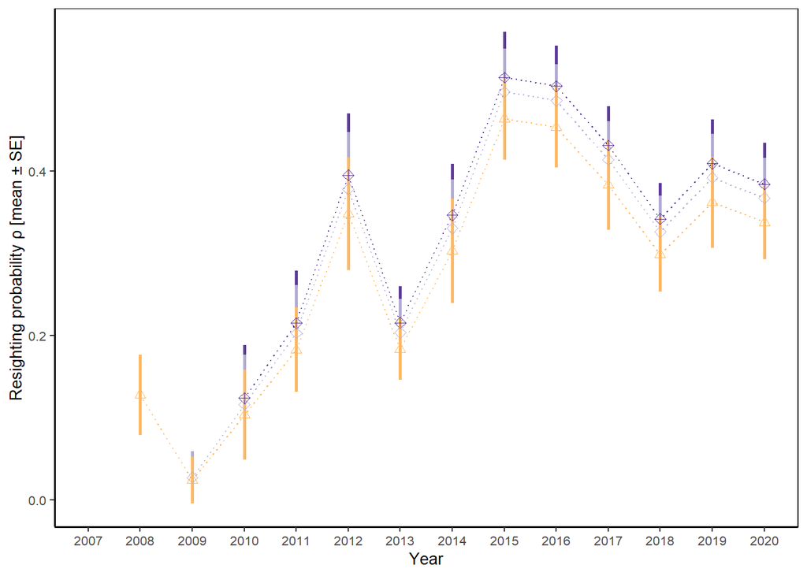

```r
## derive ageclass-specfic annual survival estimates
df.p.age <- lapply(rownames(p.mod.avg), function(row) {
  x <- stringr::str_split(row, " ")[[1]]
  data.frame(parameter = x[1],
             cohort = substr(x[3], 2, nchar(x[3])),
             year = as.numeric(substr(x[5], 2, nchar(x[5]))))
}) %>%
  do.call("rbind",.) %>%
  cbind(p.mod.avg) %>%
  mutate(ageclass = case_when(
    age == 0 ~ 'CY1',
    age == 1 ~ 'CY2',
    age == 2 ~ 'CY3',
    age %in% 3:13 ~ 'CY4plus' ## 3:13 are identical
  ))

p.res <-
  ggplot(filter(df.p.age, age %in% 1:3), aes(x = year, y = estimate, group = age)) +
  geom_line(lty = "dotted", aes(col = age)) +
  geom_errorbar(aes(ymin = estimate - se, ymax = estimate +se,  color = age), width = 0, size = 1) +
  geom_point(aes(col = age, shape = age), size = 2) +
  theme_classic() +
  theme(
    axis.line = element_line(size = .7, color = "black"),
    legend.position = "none",
    panel.background = element_rect(fill = NA),
    panel.border = element_rect(fill = NA),
    text = element_text(size = 10)) +
  scale_color_manual(values = c("#FDB863", "#B2ABD2", "#5E3C99"),
                       labels = c("CY2", "CY3", "CY4+"),
                     name = "Age class") +
  scale_shape_manual(values = c(2, 5, 9),
                      labels = c("CY2", "CY3", "CY4+"),
                      name = "Age class") +
  #scale_y_continuous(breaks = seq(0, 0.6, 15)) +
  scale_x_continuous(breaks = seq(2007, 2020, 1), limits = c(2007, 2020)) +
  xlab("Year") +
  ylab("Resighting probability \U03C1 [mean \U00B1 SE]")
p.res
```

```r
ggsave("plots/Fig_1b_ResProb.tiff", device = "tiff", dpi = 300, width = 6, height = 4, units = "in")
```

```
## [1] 21.42877
```

```
## [1] 4.598892
```

```
## [1] 40.85527
```

```
## [1] 2.340036
```

#### Recovery probabilites

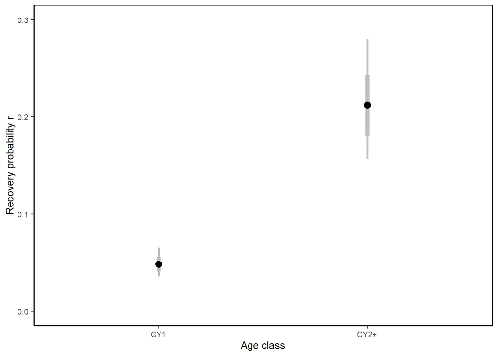

```r
##  simplify model output
df.r.age <- lapply(rownames(r.mod.avg), function(row) {
  x <- stringr::str_split(row, " ")[[1]]
  data.frame(parameter = x[1],
             age = substr(x[4], 2, nchar(x[4])),
             year = as.numeric(substr(x[5], 2, nchar(x[5]))))
}) %>%
  do.call("rbind",.) %>%
  cbind(r.mod.avg) %>%
  subset(., select = c(estimate, se, lcl, ucl, age))
df.r.age$age <- ifelse(df.r.age$age == "0", "CY1", "CY2+")

p.recov <- ggplot(data = df.r.age, aes(x = age, y = estimate)) +
  geom_errorbar(aes(ymin = lcl, ymax = ucl), width = 0, size = 1, col = "Grey") +
  geom_errorbar(aes(ymin = estimate - se, ymax = estimate + se),
                width = 0, size = 2, col = "Grey") +
  geom_point(size = 3, shape = 19, col = "Black") +
  theme_classic() +
  theme(
    axis.line = element_line(size = .7, color = "black"),
    panel.background = element_rect(fill = NA),
    panel.border = element_rect(fill = NA),
    text = element_text(size = 10)) +
  scale_y_continuous(limits = c(0, 0.3), breaks = seq(0, 0.3, 0.1)) +
  xlab("Age class") +
  ylab("Recovery probability r")
p.recov
```

#### Fidelity (F)

All substantially supported models suggest either constant or sex-dependent survival probabilities, while only a minor fraction of all supported models includes a sex effect. Hence, for visualisation purposes, only one point estimate for each sex is displayed.

```r
## estimates are essentially invariant based on model weights
## Female mean estimate
mean(F.mod.avg$estimate[F.mod.avg$Sex == "Female"])
```

```
## [1] 0.8900286
```

```r
## variation
var(F.mod.avg$estimate[F.mod.avg$Sex == "Female"])
```

```
## [1] 6.657641e-07
```

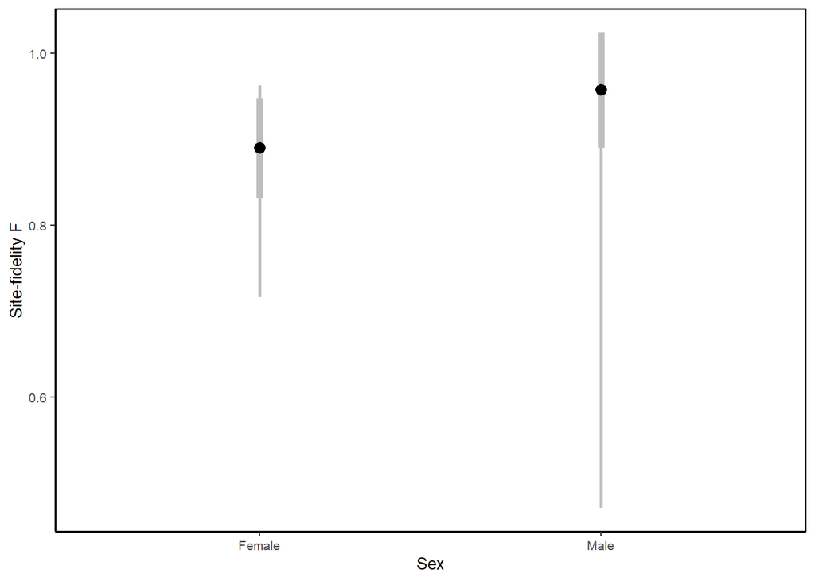

```r
F.mod.avg$SE = F.mod.avg$se

df.F <- data.frame(
  Sex = c("Female", "Male"),
  estimate =
    DBChecks::summary_stats(F.mod.avg,
                            measurevar = "estimate",
                            groupvars = c("Sex"))[["estimate"]],
  lcl =
    DBChecks::summary_stats(F.mod.avg,
                            measurevar = "lcl",
                            groupvars = c("Sex"))[["lcl"]],
  ucl =
    DBChecks::summary_stats(F.mod.avg,
                            measurevar = "ucl",
                            groupvars = c("Sex"))[["ucl"]],
  se =
    DBChecks::summary_stats(F.mod.avg,
                            measurevar = "SE",
                            groupvars = c("Sex"))[["SE"]])

p.F <- ggplot(df.F, aes(x = Sex, y = estimate)) +
  geom_errorbar(aes(ymin = lcl, ymax = ucl), width = 0, size = 1, col = "Grey") +
  geom_errorbar(aes(ymin = estimate - se, ymax = estimate + se),
                width = 0, size = 2, col = "Grey") +
  geom_point(size = 3, shape = 19, col = "Black") +
  theme_classic() +
  theme(
    axis.line = element_line(size = .7, color = "black"),
    panel.background = element_rect(fill = NA),
    panel.border = element_rect(fill = NA),
    text = element_text(size = 10)) +
  xlab("Sex") +
  ylab("Site-fidelity F")
p.F
```

```r
ggsave("plots/Fig_1_AgeEffect.tiff", device = "tiff", dpi = 300, width = 6, height = 4, units = "in")
```

### Multiplot

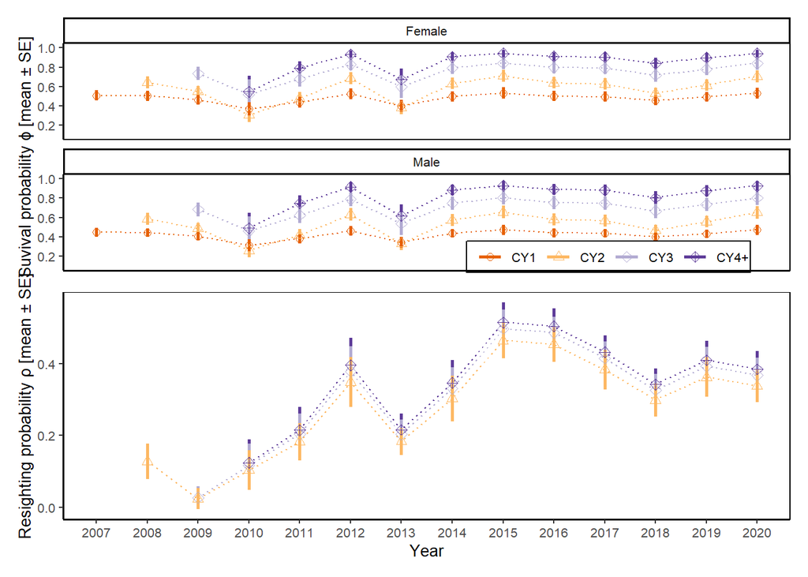

```r
p.top <- p.age + theme(axis.text.x = element_blank(),
              axis.title.x = element_blank(),
              axis.ticks.x = element_blank())
p.bot <- p.res
p.top / p.bot
```

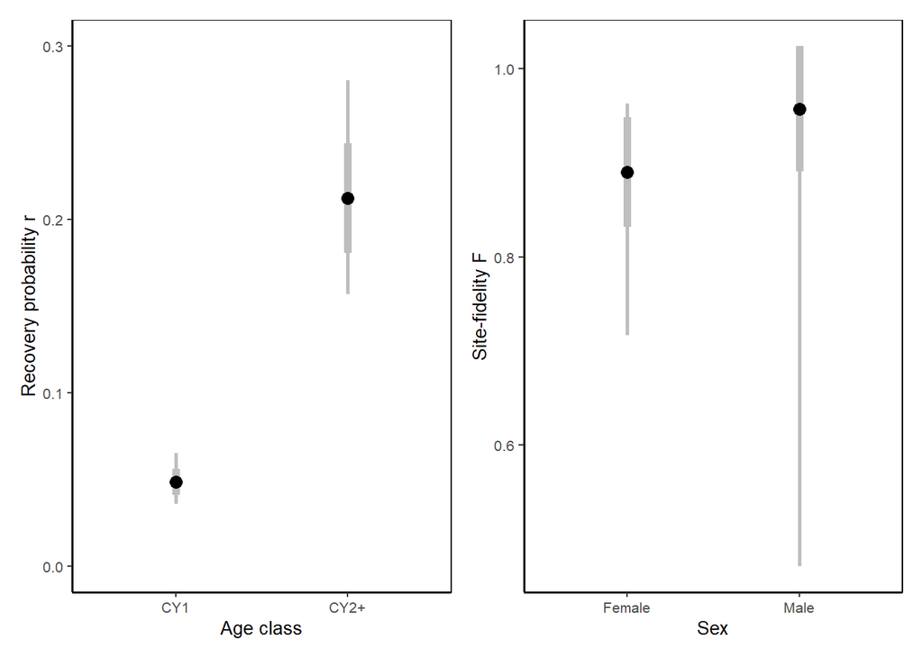

```r
ggsave("plots/Fig_1_S_Age_p_Age.tiff", device = "tiff", dpi = 300,
       width = 6, height = 6, units = "in")

p.recov + p.F
```

```r
ggsave("plots/Fig_7_F_and_r_estimates.tiff", device = "tiff", dpi = 300,
       width = 6, height = 4, units = "in")
```

# D.) Known cases of first year survival

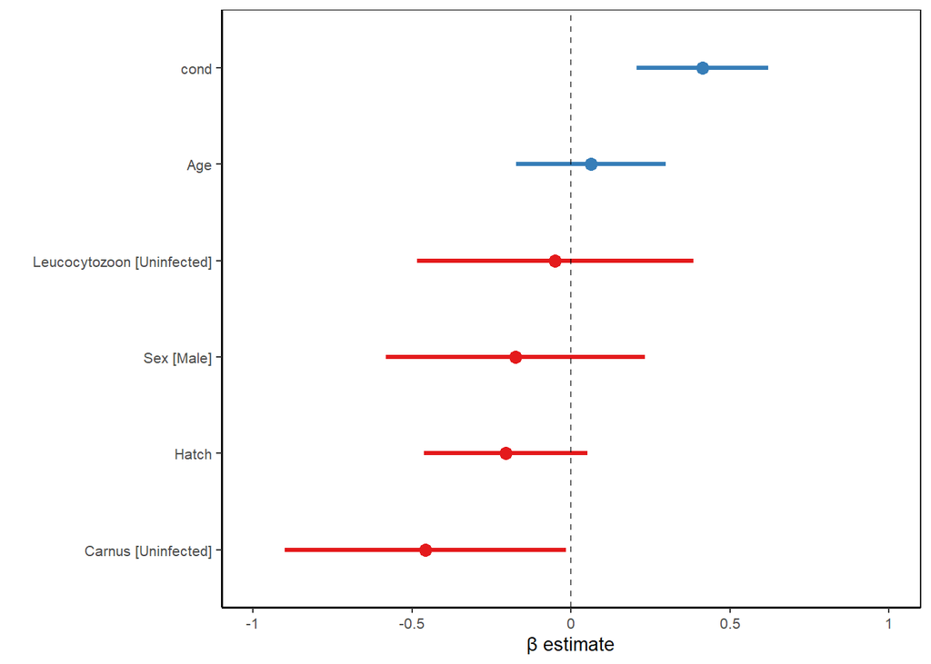

```r
## identify all cases where individuals died during the first year of life
dead <-
  filter(ringing_data,
         Dead == 'Yes',
         !CauseDeath %in% c('Jumper', 'Poisoned', 'Shot')) %>%
  mutate(HatchingDate = as.Date(paste0(Year, "-01-01")) + Hatch) %>%
  mutate(DaysSinceHatching = as.Date(DateDeath) - HatchingDate) %>%
    filter(., DaysSinceHatching <= 365)

dead <- dead$Ring

## Identify all cases where individuals where alive after completing the first
## year of life, i.e. were resighted
alive <- resighting_data %>%
  filter(DaysSinceHatching > 365)
alive <- alive$Ring %>% unique()

## merge to dataframe
df <- data.frame(Ring = c(dead, alive),
                 Group = c(rep("Dead", length(dead)), rep("Alive", length(alive)))) %>%
  left_join(., ringing_data, by = "Ring") %>%
  mutate(surv = ifelse(Group == "Dead", 0, 1)) %>%
  mutate(Leucocytozoon = ifelse(Lbinom == 0, "Uninfected", "Infected")) %>%
  mutate(Carnus = ifelse(Ekto == 0, "Uninfected", "Infected")) %>%
  mutate(Morph = case_when(
    Morph == "2" ~ "Dark",
    Morph == "3" ~ "Intermediate",
    Morph == "4" ~ "Light")) %>%
  mutate(Hatch = scale(Hatch)) %>%
  mutate(Age = scale(Age_days))

model <- glmer(
  surv ~ Leucocytozoon + cond + Sex + Carnus + Hatch + Age + (1|Year) ,
               data = df,
               family = "binomial")

model.plot <- plot_model(
  model = model,
  sort.est = TRUE,
  transform = NULL,
  title = "",
  ci.lvl = .95,
  ci.style = "whisker",
  dot.size = 3,
  line.size = 1.2) +
  theme_classic() +
  theme(
    axis.line = element_line(size = .7, color = "black"),
    legend.background = element_rect(fill = NA),
    legend.direction = "horizontal",
    legend.position = c(.8,.05),
    panel.background = element_rect(fill = NA),
    panel.border = element_rect(fill = NA),
    text = element_text(size = 10)) +
  geom_hline(yintercept = 0, lty = "dashed", alpha = .6) +
  ylab("\U03B2 estimate") + xlab("")
model.plot
```

```r
ggsave("plots/Fig_2_KnownCases.tiff", device = "tiff", dpi = 300, width = 6, height = 4, units = "in")
tab_model(model,
          show.stat = T,
          string.est = "Estimate",
          string.ci = "95% CI",
          transform = NULL,
          collapse.ci = F)
```

|  | surv |  |  |  |
| --- | --- | --- | --- | --- |
| Predictors | Estimate | 95% CI | Statistic | p |
| (Intercept) | 1.48 | 0.87 – 2.09 | 4.78 | **<0.001** |
| Leucocytozoon [Uninfected] | -0.05 | -0.49 – 0.38 | -0.23 | 0.821 |
| cond | 0.41 | 0.21 – 0.62 | 3.90 | **<0.001** |
| Sex [Male] | -0.18 | -0.58 – 0.23 | -0.84 | 0.400 |
| Carnus [Uninfected] | -0.46 | -0.90 – -0.02 | -2.03 | **0.043** |
| Hatch | -0.20 | -0.46 – 0.05 | -1.56 | 0.119 |
| Age | 0.06 | -0.17 – 0.30 | 0.52 | 0.603 |
| Random Effects |  |  |  |  |
| σ<sup>2</sup> | 3.29 |  |  |  |
| τ<sub>00</sub> <sub>Year</sub> | 0.44 |  |  |  |
| ICC | 0.12 |  |  |  |
| N <sub>Year</sub> | 12 |  |  |  |
| Observations | 583 |  |  |  |
| Marginal R<sup>2</sup> / Conditional R<sup>2</sup> | 0.062 / 0.172 |  |  |  |

#### Acknowledgements

The implemenation for calculating the adjusted $\hat C$ via bootstrapping was based on a modified R code created by Michael J. Conroy (accessed from https://sites.google.com/site/cmrsoftware/lecture-lab-schedule/6---model-fit-and-mmi/methods-for-assessing-fit)

## Literature cited

[^1]: Hurrell, J.W., Kushnir, Y., Ottersen, G. & Visbeck, M. (2003). An overview of the North Atlantic oscillation. The North Atlantic Oscillation: climatic significance and environmental impact, 134, 1–35.